# Method

Erin M. Buchanan

Last Update 2024-05-09

## Languages

| Table 1. Language Data Collection Sample Sizes, Accuracy, and Median Response Time Language | Table 1. Language Data Collection Sample Sizes, Accuracy, and Median Response Time N Include | Table 1. Language Data Collection Sample Sizes, Accuracy, and Median Response Time N Exclude | Table 1. Language Data Collection Sample Sizes, Accuracy, and Median Response Time Proportion Correct | Table 1. Language Data Collection Sample Sizes, Accuracy, and Median Response Time Median Time |
| --- | --- | --- | --- | --- |
| Arabic | 133 | 102 | 0.92 | 18.67 |
| Czech | 1,074 | 362 | 0.94 | 19.76 |
| Danish | 829 | 167 | 0.93 | 18.70 |
| German | 2,628 | 469 | 0.94 | 19.02 |
| Greek | 689 | 130 | 0.94 | 18.48 |
| English | 5,122 | 1,607 | 0.92 | 17.64 |
| Spanish | 1,468 | 284 | 0.94 | 18.04 |
| Farsi | 192 | 110 | 0.95 | 17.71 |
| French | 869 | 142 | 0.95 | 17.68 |
| Hebrew | 247 | 74 | 0.92 | 16.63 |
| Hindi | 1 | 2 | 0.82 | 27.39 |
| Hungarian | 718 | 180 | 0.94 | 17.94 |
| Italian | 1,085 | 142 | 0.95 | 18.10 |
| Japanese | 1,165 | 680 | 0.94 | 18.69 |
| Korean | 975 | 601 | 0.91 | 17.59 |
| Dutch | 184 | 25 | 0.93 | 17.60 |
| Norwegian | 85 | 17 | 0.93 | 20.08 |
| Polish | 1,188 | 318 | 0.94 | 19.15 |
| Portuguese | 1,178 | 332 | 0.93 | 18.25 |
| Romanian | 741 | 174 | 0.94 | 19.65 |
| Russian | 1,806 | 956 | 0.94 | 19.68 |
| Slovak | 381 | 391 | 0.94 | 18.68 |
| Slovenian | 31 | 10 | 0.95 | 18.89 |
| Serbian | 681 | 109 | 0.94 | 21.01 |
| Thai | 65 | 20 | 0.95 | 18.34 |
| Turkish | 2,218 | 790 | 0.93 | 17.83 |
| Urdu | 315 | 381 | 0.88 | 22.15 |
| Simplified Chinese | 729 | 291 | 0.93 | 17.75 |
| Traditional Chinese | 174 | 67 | 0.92 | 18.05 |

## Ethics and Research Labs

We did not collect any identifiable private or personal data as part of the experiment. This project was approved by Harrisburg University of Science and Technology conforming to all relevant ethical guidelines and the Declaration of Helsinki, with special care to conform to the General Data Protection Regulation (GDPR; eugdpr.org). No global exclusion criteria for participating in the study were used, except for a minimum age requirement of 18 years. Please see the analysis section below for other participant and trial level exclusion criteria related to analyses.

133 labs completed ethics documentation for data collection, and 126 labs in 41 geopolitical regions collected data (i.e., *N* >= 1) for the study. Each data collection lab obtained local ethical review (81), relied on the ethical review provided by Harrisburg University (31), or provided evidence of no required ethical review (14). The supplemental materials provide links to the IRB approvals on the Open Science Framework (OSF) and a table of participating labs with their data collection information, which includes languages sampled, geopolitical region of the team, compensation procedure and amount, online versus in person testing, and testing type (individual participants or classroom type settings). This information can be matched to study data using the lab code that is present in the participant and trial level files. Figure 1 demonstrates a visualization of the entire sample using the lab’s geopolitical region during data collection.

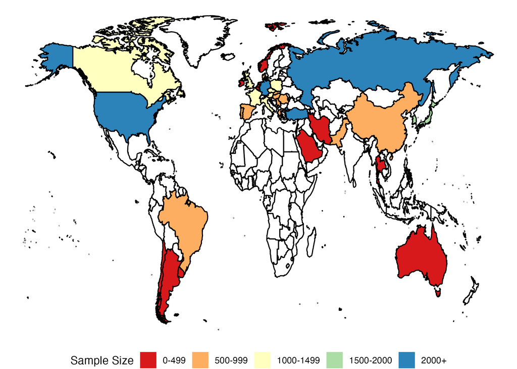

*Figure 1*. Binned sample sizes based on research lab geopolitical region demonstrating the full data available for reuse from the project.

## Participants

35,904 participants opened the link to the study, and 31,645 proceeded through to complete at least one trial of the study trials (i.e., past the practice trials). Of these participants, 26,971 were retained for analysis because they met our three participant level inclusion rules: 1) at least 18 years of age, 2) completed at least 100 trials, and 3) scored at least 80% correct. All exclusion criteria are summarized in the results section for clarity. The pre-registered plan calculated accuracy as $\frac{N_{Correct}}{N_{Trials Seen}}$ in the planned scripts; however, an administrative team discussion revealed that the pre-registered report could be interpreted as $\frac{N_{Correct}}{N_{Answered}}$. If accuracy is recalculated using this formula, 28,162 participants would be included for analysis. This report will use the stricter criterion of accuracy for analysis, while the analysis using the rescored accuracy can be found in our supplemental materials. The analyses reported below only examine languages that met the minimum data criteria, which includes 32,897 total participants, 29,155 who completed at least one trial, 25,163 who met the strict inclusion rules, and 26,197 that met the rescored version of the inclusion rule for accuracy. Descriptive statistics about participants are provided below in the results for the 25,163 participants who met the strict inclusion rules.

[^1]: Participant accuracy scores were calculated, and then the average of participant accuracy scores for each language were calculated
[^2]: We present the results combined when discussing trials or global information, but separated when examining item or priming level effects